# Introduction to writing functions in R

Jessi Kehe

Be sure to read R4DS Chapter 19 for more details on writing function in R!

#### An R function has the general form displayed in the function below.

What does this function do?  
What kind of input does it take?  
What output will it give?  
What’s a reasonable name (other than `function_name`?

```r
function_name <- function(input_parameter_1, input_parameter_2){
  ## code for the function
  output <- input_parameter_1 + input_parameter_2
  return(output)
}

## Run the function!
function_name(1,-5)
```

```
## [1] -4
```

#### Why use functions?

- Avoids copying and pasting the same code multiple times, which helps to limit typos
- If you have copied and pasted code multiple times, and then realize you need to make an update, you have to make the update to all the copies
- It can be easier to read and follow code when it is nicely organized as functions

Let’s write a function that does one thing if the input is odd and another thing if the input is even.  
We’ll use a conditional statement here. Note that the conditions (`!is.numeric(x)` and `(x %% 2)==0` in the function below) must evaluate to `TRUE` or `FALSE`.

```r
odd_or_even <- function(x){
  if(!is.numeric(x)){
    print("This is not numeric")
  }else if((x %% 2)==0){ ## %% = modulus operator
    print("This number is even")
  }else{
    print("This number is odd")
  }
}

odd_or_even(100)
```

```
## [1] "This number is even"
```

```r
odd_or_even(-2)
```

```
## [1] "This number is even"
```

```r
odd_or_even(-9)
```

```
## [1] "This number is odd"
```

```r
odd_or_even("abc")
```

```
## [1] "This is not numeric"
```

Instead of printing “This is not numeric”, we may instead want to stop the function and notify the user that their input is not as expected.

```r
odd_or_even2 <- function(x){
  if(!is.numeric(x)){
    stop("Input should be numeric")
  }

  if((x %% 2)==0){ ## %% = modulus operator
    print("This number is even")
  }else{
    print("This number is odd")
  }
}

odd_or_even2(100)
```

```
## [1] "This number is even"
```

```r
odd_or_even2(-2)
```

```
## [1] "This number is even"
```

```r
odd_or_even2(-9)
```

```
## [1] "This number is odd"
```

```r
# odd_or_even2("abc")
```

#### For loops

For loops can be useful in the context of functions; we’ve already used them a bit this semester.

```r
i <- 1
i
```

```
## [1] 1
```

```r
i <- 2
i
```

```
## [1] 2
```

```r
i <- 3
i
```

```
## [1] 3
```

```r
i <- 4
i
```

```
## [1] 4
```

```r
i <- 5
i
```

```
## [1] 5
```

```r
for(i in 1:5){ ## i is the index here
  print(i)
}
```

```
## [1] 1
## [1] 2
## [1] 3
## [1] 4
## [1] 5
```

```r
for(wisconsin in -2:8){ ## wisconsin is the index here
  print(wisconsin)
}
```

```
## [1] -2
## [1] -1
## [1] 0
## [1] 1
## [1] 2
## [1] 3
## [1] 4
## [1] 5
## [1] 6
## [1] 7
## [1] 8
```

Suppose we want to generate samples of size 10 from a Normal distribution with a mean of 4 and a standard deviation of 2, and calculate the sample means.

```r
get_sample_mean <- function(n, mean=0, sd=1){ ## defaults to a standard normal distribution
  random_sample <- rnorm(n, mean, sd)
  sample_mean <- mean(random_sample)
  return(sample_mean)
}

get_sample_mean(n=10)
```

```
## [1] -0.1553142
```

```r
get_sample_mean(n=10, mean=4, sd=2)
```

```
## [1] 2.982007
```

Now suppose we want to repeat this a bunch of times. We can do this in a for-loop.

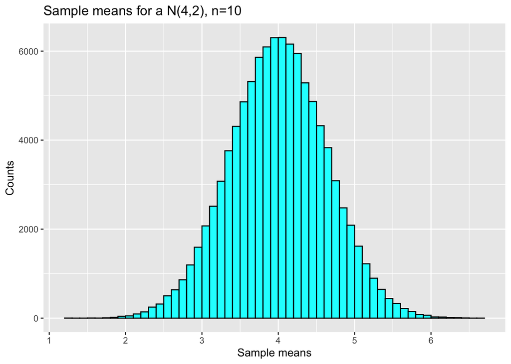

```r
N <- 100000
n <- 10
mean <- 4
sd <- 2
sample_means <- c() ## store the values in this variable

for(i in 1:N){
  sample_means[i] <- get_sample_mean(n,mean,sd)
}

df_sample_means <- tibble(means = sample_means)
ggplot(df_sample_means, aes(means)) +
  geom_histogram(binwidth=.1, boundary=0, color="black",fill="cyan") +
  xlab("Sample means") +
  ylab("Counts") +
  ggtitle(paste0("Sample means for a N(",mean, ",",sd,")", ", n=",n))
```

```r
## What happens if you increase n?
```

Or we could turn the for-loop into a function as well!

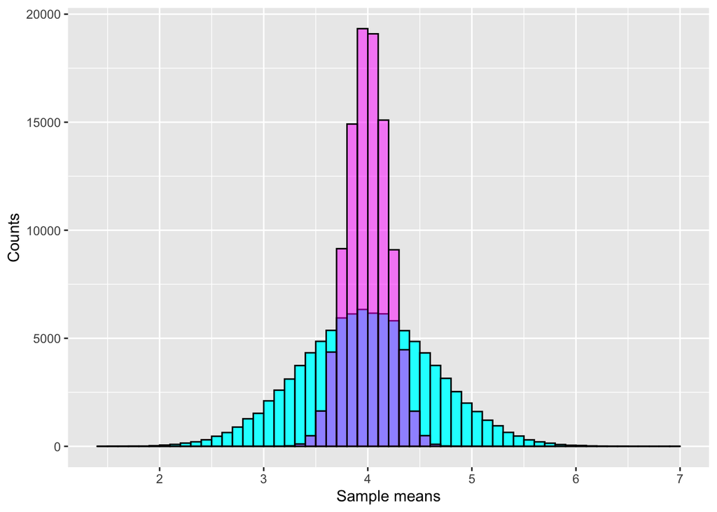

```r
N_sample_means <- function(N, n, mean, sd){
  sample_means <- c() ## store the values in this variable
  for(i in 1:N){
    sample_means[i] <- get_sample_mean(n,mean,sd)
  }
  return(tibble(means = sample_means))
}

df_sample_means_10 <- N_sample_means(N=100000, n=10, mean=4, sd=2)
df_sample_means_100 <- N_sample_means(N=100000, n=100, mean=4, sd=2)

ggplot(df_sample_means_10, aes(means)) +
  geom_histogram(binwidth=.1, boundary=0, color="black",fill="cyan") +
  geom_histogram(df_sample_means_100, mapping=aes(x=means), binwidth=.1, boundary=0, color="black",fill="magenta", alpha=.5) +
  xlab("Sample means") +
  ylab("Counts")
```